# Board_game_popularity_analysis_project

Simona Liao, Celeste Zeng

2020/1/22

# The Current Trending of Board Games

## I. The board games’ development across years

Nowadays, with more and more new types of entertainment emerges, such as video games and social media, the classic board games seem to be outdated. Is it the truth? The statistics tell another story.

According to the histogram below, the number of board games has been constantly growing and achieve a peak around 2010 - 2015.

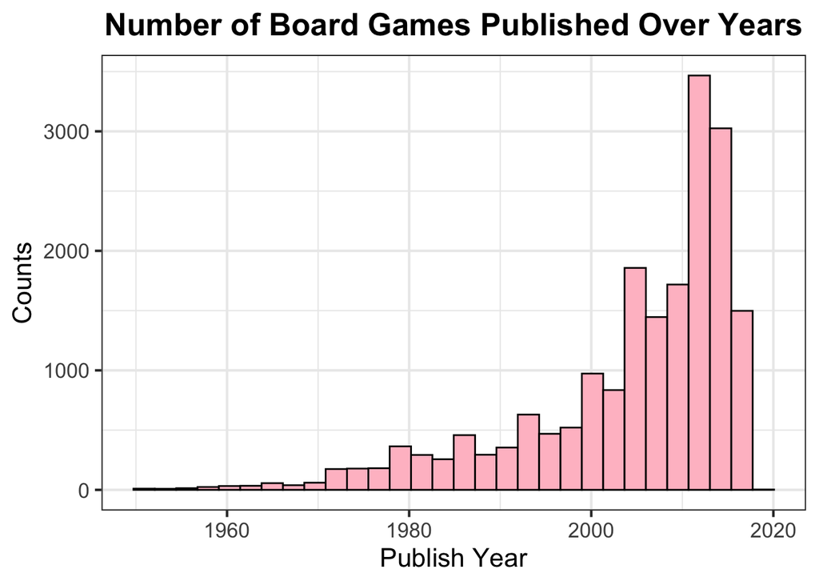

Similarly, in the graph below, the rating of board games slowly grows from 1950 to 2000 and increases more obviously starting from 2000.

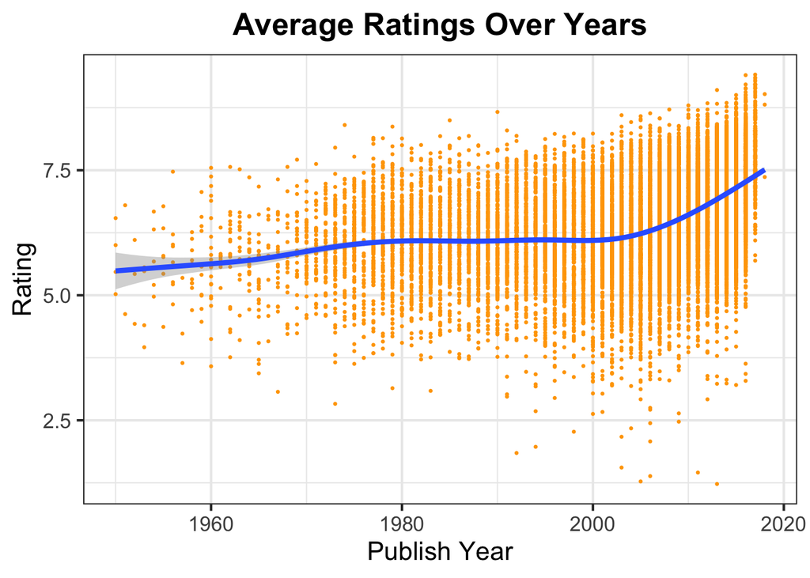

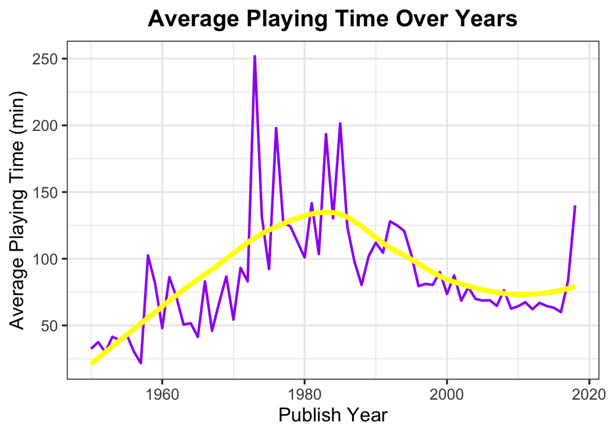

## II. Popularity of Board Games

What keeps board games so popular over the years and what kinds of board games do people like most? This report will discuss the popularity of board games from four perspectives: the mechanics used in the game, the game category, the game complexity, and the number of players in the game.

First, it is a bar chart showing that what are the top 100 most complex games’ mechanics and their corresponding counts. The chart only includes data of games which are rated by over 2000 users to avoid biased high complexity rating coming from small sample size. The graph only shows the mechanics whose counts are greater than 6 since counts that are smaller than or equal to 6 are trivial while having 100 games. Nonetheless, this graph does not illustrate relative complexity: although the count of dice rolling games is greater than that of trading games, it does not mean that dice rolling games are more difficult to play. Instead, the graph shows what are the most common mechanics to which the top 100 most complex games belong to. Therefore, among the top 100 most complex games, their most common mechanics are dice rolling, variable player powers, and hand management.

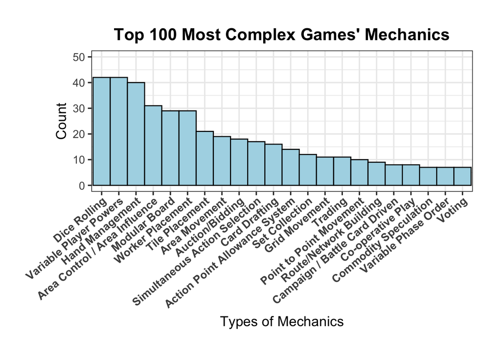

Second, it is a bar chart showing what are the top 100 most popular games’ categories and their corresponding counts. The chart only includes data of games which are rated by over 2000 users to avoid biased high rating coming from small sample size. The graph only shows the categories whose counts are greater than 6 since counts that are smaller than or equal to 6 are trivial while having 100 games. However, the graph does not demonstrate relative popularity: although the count of economic games is greater than that of dice games, it does not mean that economic games are more popular. Instead, the graph shows what are the most common categories to which the top 100 most popular games belong to. Therefore, among the top 100 most popular games, their most common categories are expansion for base-game, economic games, as well as science fiction games.

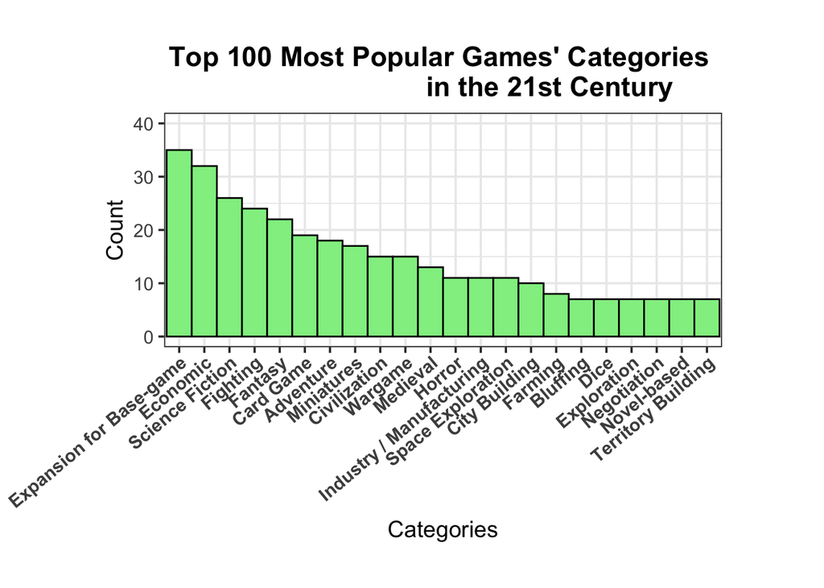

Third, based on the graph below, ratings increase and the range of ratings also decreases while the game complexity increase. Thus, ratings correlate with the game complexity positively, meaning that people tend to prefer more complicated board games. (Data with 0 game complexity are excluded.)

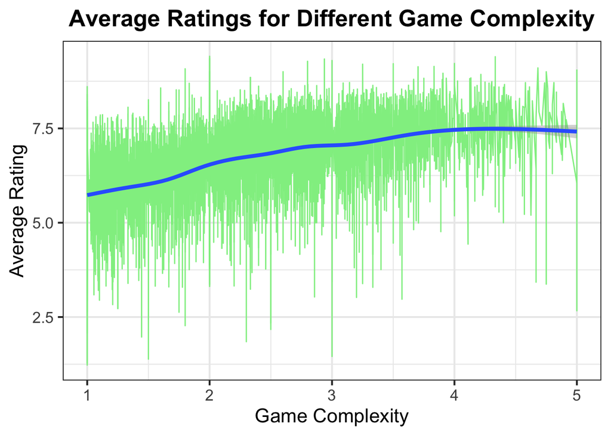

Lastly, the first boxplot depicts the relationship between ratings and the number of maximum players in board games and the second depicts the relationship between ratings and the number of minimum players. There isn’t a clear relationship between the ratings and the number of players based on boxplots, meaning that people may don’t have a preference over games with fewer participants or more participants. (These boxplots only includes data with max player and min players more than 0 people and less than 10 people to avoid the influence of extreme values.)

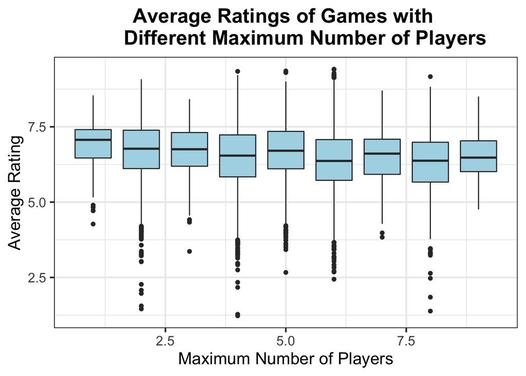

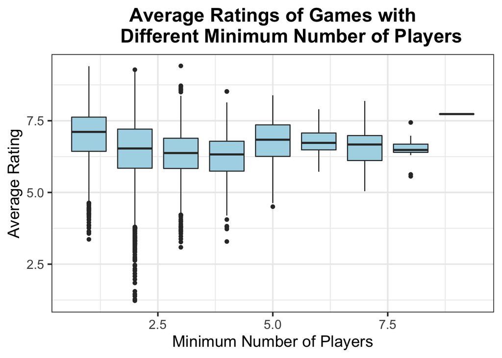

## III. Conclusion

After completing this project we have the following discoveries.

For the factors that might influence the popularity of board games: 1) The majority of the most complex games have the following mechanics in common: dice rolling, variable player powers, and hand management; 2) The majority of the most popular games belong to the following categories: expansion for base-game, economic games, as well as science fiction games; 3) Games with higher complexity are more likely to receive higher ratings; 4) The numbers of minimum and maximum players of a game may not affect its rating.

(All the graphs above only concludes data of board games which are published after 1950 and have more than 25 ratings.)

## Code Appendix

```r
library(tidyverse)
boardGame <- read_csv("https://raw.githubusercontent.com/bryandmartin/STAT302/master/docs/Projects/project1/board_game_raw.csv")
write_csv(boardGame, path = "./data/boardGame.csv")

# filters the data published after 1950 and and has number of ratings less than 25
boardGame <- boardGame %>%
  filter(yearpublished >= 1950 & users_rated >= 25)

# plots the counts of board games published across years
ggplot(data = boardGame,
       aes(x = yearpublished)) +
  geom_histogram(color = "black", fill = "pink") +
  theme_bw(base_size = 16) +
  labs(title = "Number of Board Games Published Over the Years",
       x = "Publish Year",
       y = "Counts") +
  theme(plot.title = element_text(hjust = 0.5, face = "bold"))

# plots the relationship between average rating and published year
ggplot(data = boardGame,
       aes(x = yearpublished, y = average_rating)) +
  geom_point(size = 0.5, color = "orange") +
  geom_smooth(size = 1.5)+
  theme_bw(base_size = 16) +
  labs(title = "Average Ratings Over the Years",
       x = "Publish Year",
       y = "Rating") +
  theme(plot.title = element_text(hjust = 0.5, face = "bold"))

# filters the data with mean playing time over 400 minutes and groups them by published year
boardGame_05 <- boardGame %>%
  group_by(yearpublished) %>%
  summarize(mean_playtime = mean(playingtime)) %>%
  filter(mean_playtime < 400)

# plots the relationship between average playing time and published year
playtime_plot <- ggplot(data = boardGame_05,
       aes(x = yearpublished, y = mean_playtime)) +
  geom_line(size = 1, color = "purple") +
  geom_smooth(size = 2, color = "yellow", se = FALSE)+
  theme_bw(base_size = 16) +
  labs(title = "Average Playing Time Over the Years",
       x = "Publish Year",
       y = "Average Playing Time (min)") +
  theme(plot.title = element_text(hjust = 0.5, face = "bold"))

library(splitstackshape)
# filter the data to only consider games which were
# rated by over 2000 users
temp1 <- filter(boardGame,users_rated >= 2000)
# rearrange the data so that we get the games with top 100
# highest compexity rating
temp1 <- arrange(temp1, desc(average_complexity))
temp1 <- temp1[1 : 100,]
# split the mechanic coloum in "long direction"
# so we can include all mechanies of each game in the graph
temp1 <- cSplit(temp1, "mechanic", direction = "long")
# only the mechanics whose counts are > 6 can appear in the graph
temp3 <- count(temp1, mechanic, sort = T) %>%
          rename(count = n) %>%
          filter(count > 6)
# draw a bar chart to show what top 100 most complex games' mechanics are
mechanic_count_plot <- ggplot(temp3, aes(x = reorder(mechanic, -count), y = count)) +
                        geom_bar(width = 1, color = "black", fill = "lightblue", stat = "identity") +
                        labs(title = "Top 100 Most Complex Games' Mechanics",
                             x = "Types of Mechanics", y = "Count")  +
                        theme_bw(base_size = 14) +
                        theme(plot.margin = unit(c(1, 1, 1, 2), "cm"),
                              plot.title = element_text(hjust = 0.5, face = "bold"),
                              axis.text.x = element_text(angle = 40, hjust = 1, vjust = 1.02, face = "bold")) +
                        ylim(c(0 , 50))

# filter the data to only consider games which were
# rated by over 2000 users
temp2 <- filter(boardGame,users_rated >= 2000, yearpublished >= 2000)
# rearrange and filter the data so that we get the games with top 100
# highest rating
temp2 <- arrange(temp2, desc(average_rating))
temp2 <- temp2[1 : 100,]
# split the category coloum in "long direction"
# so we can include all categories of each game in the graph
temp2 <- cSplit(temp2, "category", direction = "long")
# only the categories whose counts are > 6 can appear in the graph
temp4 <- count(temp2, category, sort = T) %>%
          rename(count = n) %>%
          filter(count > 6)
# draw a bar chart to show what top 100 most popular games' categories are
cate_count_plot <- ggplot(temp4, aes(x = reorder(category, -count), y = count)) +
                       geom_bar(width = 1, color = "black", fill = "lightgreen", stat = "identity") +
                       labs(title = "Top 100 Most Popular Games' Categories
                            in the 21st Century",
                            x = "Categories", y = "Count")  +
                       theme_bw(base_size = 14) +
                       theme(plot.margin = unit(c(1, 2.2, 1, 2.3), "cm"),
                             plot.title = element_text(hjust = 0.5, face = "bold"),
                             axis.text.x = element_text(angle = 40, hjust = 1, vjust = 1.02, face = "bold")) +
                       ylim(c(0 , 40))

# plot the relationship between average rating and game complexity
boardGame_01 <- boardGame %>%
  filter(average_complexity > 0)
ggplot(data = boardGame_01,
       aes(x = average_complexity, y = average_rating)) +
  geom_line(size = 0.5, color = "lightgreen") +
  geom_smooth(size = 1.5) +
  theme_bw(base_size = 16) +
  labs(title = "Average Ratings for Different Game Complexity",
       x = "Game Complexity",
       y = "Average Rating") +
  theme(plot.title = element_text(hjust = 0.5, face = "bold"))

# plots the relationship between average rating and maximum / minimum number of players
boardGame_02 <- boardGame %>%
  filter(maxplayers < 10 & maxplayers > 0)
ggplot(data = boardGame_02,
       aes(x = maxplayers, y = average_rating, group = maxplayers)) +
  geom_boxplot(fill = "lightblue") +
  theme_bw(base_size = 16) +
  labs(title = "Average Ratings of Games with
       Different Maximum Number of Players",
       x = "Maximum Number of Players",
       y = "Average Rating") +
  theme(plot.title = element_text(hjust = 0.5, face = "bold"))

boardGame_03 <- boardGame %>%
  filter(minplayers < 10 & minplayers > 0)
ggplot(data = boardGame_03,
       aes(x = minplayers, y = average_rating, group = minplayers)) +
  geom_boxplot(fill = "lightblue") +
  theme_bw(base_size = 16) +
  labs(title = "Average Ratings of Games with
       Different Minimum Number of Players",
       x = "Minimum Number of Players",
       y = "Average Rating") +
  theme(plot.title = element_text(hjust = 0.5, face = "bold"))
```